# A-20094-2020StatComp

## 12-01

## Exercise：

$\textbf{Question: }$ Write an Rcpp function for Exercise 9.4 (page 277, Statistical Computing with R).

$\textbf{Solve: }$ We write the following function with Rcpp and print the results:

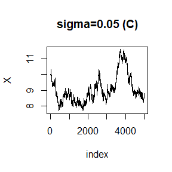

```r
library(Rcpp)

cppFunction('NumericVector rwMetropolis(double sigma, double x0, int N) {
  NumericVector x(N);
  x[0] = x0;
  NumericVector u=runif(N);
  for (int i=1;i<N;i++) {
    NumericVector y = rnorm(1, x[i-1], sigma);
    if (u[i] <= (exp(-abs(y[0])) / exp(-abs(x[i-1])))){
      x[i] = y[0];
    }
    else {
        x[i] = x[i-1];
    }
  }
  return(x);
}')

set.seed(2001)
N <- 5000
sigma <- c(.05, .3, 1.5, 10)
x0 <- 10
rw1 <- rwMetropolis(sigma[1], x0, N)
rw2 <- rwMetropolis(sigma[2], x0, N)
rw3 <- rwMetropolis(sigma[3], x0, N)
rw4 <- rwMetropolis(sigma[4], x0, N)
index=1:N
plot(index, rw1, type="l", main="sigma=0.05 (C)", ylab="X")
```

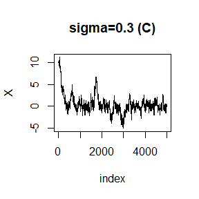

```r
plot(index, rw2, type="l", main="sigma=0.3 (C)", ylab="X")
```

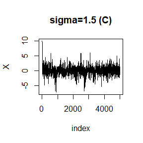

```r
plot(index, rw3, type="l", main="sigma=1.5 (C)", ylab="X")
```

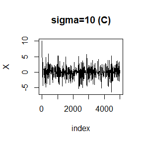

```r
plot(index, rw4, type="l", main="sigma=10 (C)", ylab="X")
```

$\textbf{Question: }$ Compare the corresponding generated random numbers with those by the R function you wrote before using the function “qqplot”.

$\textbf{Solve: }$ From the previous plot we can see that the result is similar. We plot the result of the R function. We further use the function ‘qqplot’ to compare the result with the R function.

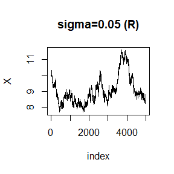

```r
f<-function(x) 0.5*exp(-abs(x))
rw.Metropolis <- function(sigma, x0, N) {
  x <- numeric(N)
  x[1] <- x0
  u <- runif(N)
  for (i in 2:N) {
    y <- rnorm(1, x[i-1], sigma)
    if (u[i] <= (f(y) / f(x[i-1])))
      x[i] <- y else {
        x[i] <- x[i-1]
      }
  }
  return(x)
}
set.seed(2001)
N <- 5000
sigma <- c(.05, .3, 1.5, 10)
x0 <- 10
rw.1 <- rw.Metropolis(sigma[1], x0, N)
rw.2 <- rw.Metropolis(sigma[2], x0, N)
rw.3 <- rw.Metropolis(sigma[3], x0, N)
rw.4 <- rw.Metropolis(sigma[4], x0, N) #result of the R function
index=1:N
plot(index, rw.1, type="l", main="sigma=0.05 (R)", ylab="X")
```

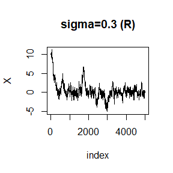

```r
plot(index, rw.2, type="l", main="sigma=0.3 (R)", ylab="X")
```

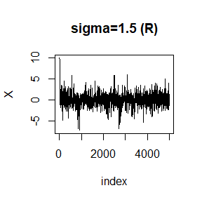

```r
plot(index, rw.3, type="l", main="sigma=1.5 (R)", ylab="X")
```

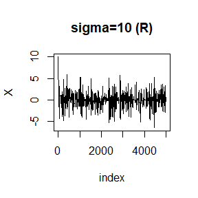

```r
plot(index, rw.4, type="l", main="sigma=10 (R)", ylab="X")
```

We now compare the results of the two methods by qqplots:

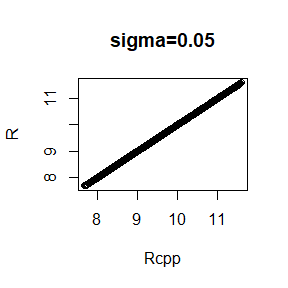

```r
qqplot(rw1,rw.1,main='sigma=0.05',xlab='Rcpp',ylab='R')
```

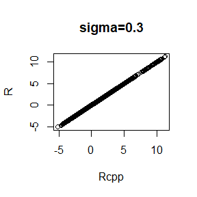

```r
qqplot(rw2,rw.2,main='sigma=0.3',xlab='Rcpp',ylab='R')
```

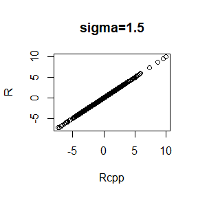

```r
qqplot(rw3,rw.3,main='sigma=1.5',xlab='Rcpp',ylab='R')
```

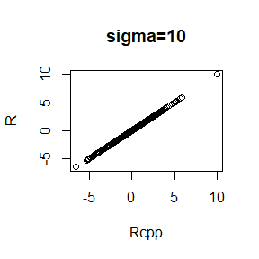

```r
qqplot(rw4,rw.4,main='sigma=10',xlab='Rcpp',ylab='R')
```

From the qqplots we can see that the results of two methods are very similar.

$\textbf{Question: }$ Campare the computation time of the two functions with the function “microbenchmark”.

$\textbf{Solve: }$ We now compare the computation time of the two methods:

```r
library(microbenchmark)
ts <- microbenchmark(rwR=rw.Metropolis(sigma[1], x0, N),rwC=rwMetropolis(sigma[1], x0, N))
summary(ts)[,c(1,3,5,6)]
```

```
##   expr        lq   median        uq
## 1  rwR 31.644951 33.57540 41.243101
## 2  rwC  1.851351  1.96595  2.084801
```

From the results we can see that the C function via Rcpp is much faster than the R function.

$\textbf{Question: }$ Comments your results.

$\textbf{Solve: }$ To summarize: The C function via Rcpp generate almost the same result with the R function while reduce the computation time greatly.